# R Notebook

So I think the first time-point isn’t actually correlated with survival after all. I may have been mistreding my statistics output. In any case I’d like to show how the microbiota do vary over the life of a crash.

```r
library(ggvegan)
library(plotly)
library(purrr)
library(broom)
library(flextable)
library(here)
source(here("RScripts","Initial_Processing.R"))
```

## Canonical correspondence analysis.

Overall patterns in community structure over the life time of things.

```r
#first_cca <- cca(sqrt(ratioDf) ~ DayN + Info1, data = metadata_main )
first_cca <- cca(sqrt(ratioDf) ~ DayN + Info1, data = metadata_main )
set.seed(33100)
anova(first_cca, by = "margin")
```

```
Permutation test for cca under reduced model
Marginal effects of terms
Permutation: free
Number of permutations: 999

Model: cca(formula = sqrt(ratioDf) ~ DayN + Info1, data = metadata_main)
         Df ChiSquare      F Pr(>F)
DayN      1   0.10807 3.5941  0.001 ***
Info1     1   0.09135 3.0378  0.001 ***
Residual 46   1.38320
---
Signif. codes:  0 ‘***’ 0.001 ‘**’ 0.01 ‘*’ 0.05 ‘.’ 0.1 ‘ ’ 1
```

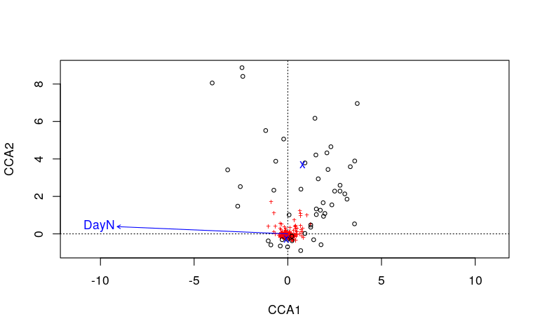

```r
plot(first_cca)
```

Ok. Lets look at how the samples evolve over time on the above plot

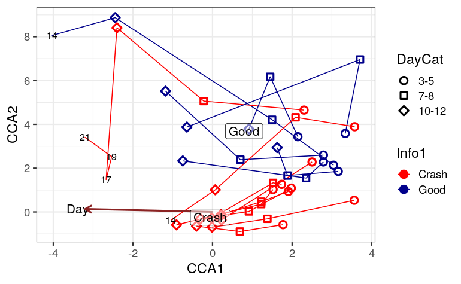

```r
first_cca_wa <- fortify(first_cca, display = "wa") %>%
  #rename(Label = label) %>% # during an update of ggvegan "Label" was changed to "label"
  left_join(metadata_main, by = c("label" = "Sample0")) %>%
  mutate(DayCat = ordered(DayCat, levels = unique(DayCat)))


early_days <- first_cca_wa %>% filter(DayN < 14) %>% mutate(DayCat = droplevels(DayCat))
late_days <- first_cca_wa %>% filter(DayN >= 14)
plt1 <- early_days %>%
  ggplot(aes(x = CCA1, y = CCA2, shape = DayCat, group = `Brood#`, color = Info1)) +
  geom_path(aes(x = CCA1, y = CCA2, color = Info1, group = `Brood#`), data = first_cca_wa, inherit.aes = FALSE) +
  geom_point(size = 3, stroke = 1.5) +
  scale_shape_manual(values = c(21, 22, 23, 1, 1, 1, 1)) +
  #scale_shape_manual(values = c(21,22,23), breaks = c("3-5", "7-8", "10-12")) +
  #scale_fill_manual(values = rep(c("green", "blue", "black"), 5)) +
  #scale_color_manual(values = c(Good = "black", Crash = "red")) +
  scale_color_manual(values = c(Good = "darkblue", Crash = "red")) +
  geom_text(data = late_days, aes(x = CCA1, y = CCA2, label = DayCat), inherit.aes = FALSE) +
  geom_text(data = first_cca %>% fortify(display = "bp") %>% filter(label != "Info1Good") %>% mutate(label = str_remove(label, "N")), inherit.aes = FALSE, aes(x = CCA1 * 3.4, y = CCA2 * 3.4, label = label), size = 5) +
  geom_segment(data = first_cca %>% fortify(display = "bp") %>% filter(label != "Info1Good"), inherit.aes = FALSE, aes(x = 0, y = 0, xend = CCA1 * 3.2, yend = CCA2 * 3.2), color = "brown4",
               arrow = arrow(length = unit(0.3, "cm")), size = 1) +
  geom_label(data = first_cca %>% fortify(display = "cn") %>% mutate(label = str_remove(label, "Info1")), inherit.aes = FALSE, aes(x = CCA1, y = CCA2, label = label), alpha = 0.5, size = 5) +
  theme_bw(base_size = 16)
plt1
```

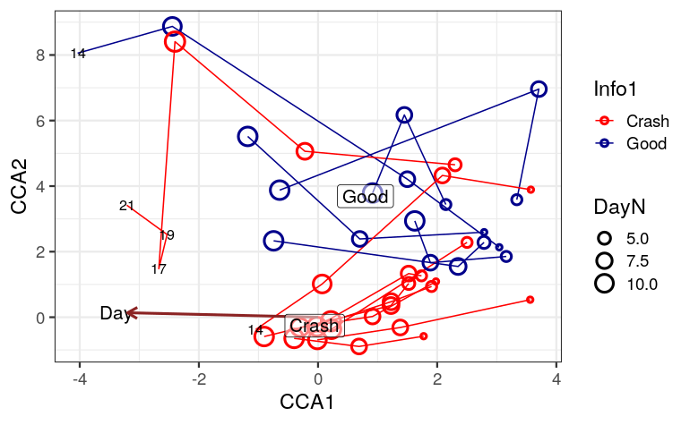

```r
plt1 <- early_days %>%
  ggplot(aes(x = CCA1, y = CCA2, group = `Brood#`, color = Info1)) +
  geom_path(aes(x = CCA1, y = CCA2, color = Info1, group = `Brood#`), data = first_cca_wa, inherit.aes = FALSE) +
  geom_point(aes(size = DayN), shape = 1, stroke = 1.5) +
  #scale_shape_manual(values = c(21, 22, 23, 1, 1, 1, 1)) +
  #scale_shape_manual(values = c(21,22,23), breaks = c("3-5", "7-8", "10-12")) +
  #scale_fill_manual(values = rep(c("green", "blue", "black"), 5)) +
  #scale_color_manual(values = c(Good = "black", Crash = "red")) +
  scale_color_manual(values = c(Good = "darkblue", Crash = "red")) +
  geom_text(data = late_days, aes(x = CCA1, y = CCA2, label = DayCat), inherit.aes = FALSE) +
  geom_text(data = first_cca %>% fortify(display = "bp") %>% filter(label != "Info1Good") %>% mutate(label = str_remove(label, "N")), inherit.aes = FALSE, aes(x = CCA1 * 3.4, y = CCA2 * 3.4, label = label), size = 5) +
  geom_segment(data = first_cca %>% fortify(display = "bp") %>% filter(label != "Info1Good"), inherit.aes = FALSE, aes(x = 0, y = 0, xend = CCA1 * 3.2, yend = CCA2 * 3.2), color = "brown4",
               arrow = arrow(length = unit(0.3, "cm")), size = 1) +
  geom_label(data = first_cca %>% fortify(display = "cn") %>% mutate(label = str_remove(label, "Info1")), inherit.aes = FALSE, aes(x = CCA1, y = CCA2, label = label), alpha = 0.5, size = 5) +
  theme_bw(base_size = 16)
plt1
```

# As above, but dropping the days after day 12

```r
metadata_limited <- metadata_main %>% filter(DayN < 14)
ratioDf_limited <- ratioDf[rownames(ratioDf) %in% metadata_limited$Sample0,]
second_cca <- cca(sqrt(ratioDf_limited) ~ DayN + Info1, data = metadata_limited)
anova(second_cca, by = "margin", permutations = 9999)
```

```
Permutation test for cca under reduced model
Marginal effects of terms
Permutation: free
Number of permutations: 9999

Model: cca(formula = sqrt(ratioDf_limited) ~ DayN + Info1, data = metadata_limited)
         Df ChiSquare      F Pr(>F)
DayN      1   0.08803 2.6896 0.0015 **
Info1     1   0.08139 2.4866 0.0053 **
Residual 41   1.34198
---
Signif. codes:  0 ‘***’ 0.001 ‘**’ 0.01 ‘*’ 0.05 ‘.’ 0.1 ‘ ’ 1
```

```r
second_cca_ix <- cca(sqrt(ratioDf_limited) ~ DayN * Info1, data = metadata_limited)
anova(second_cca_ix, by = "margin", permutations = 9999)
```

```
Permutation test for cca under reduced model
Marginal effects of terms
Permutation: free
Number of permutations: 9999

Model: cca(formula = sqrt(ratioDf_limited) ~ DayN * Info1, data = metadata_limited)
           Df ChiSquare    F Pr(>F)
DayN:Info1  1    0.0375 1.15 0.2156
Residual   40    1.3045
```

```r
Info2_Levels <- c("Best", "Ok", "Poor", "NoSurvivors")
```

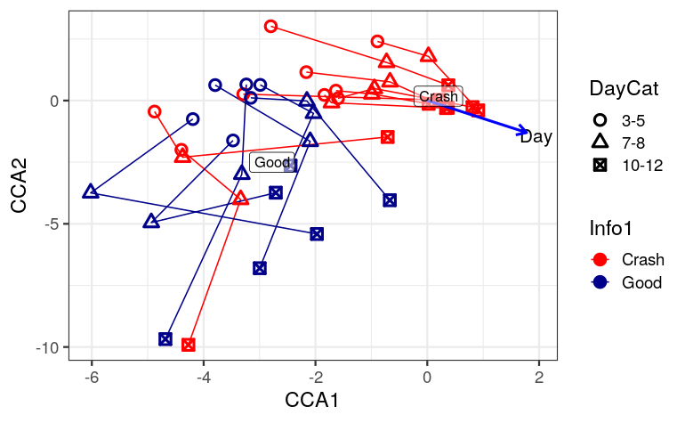

```r
larvae_cca_plotter_limited <- function(second_cca){
second_cca_wa <- fortify(second_cca, display = "wa") %>%
  left_join(metadata_main, by = c("label" = "Sample0")) %>%
  mutate(DayCat = ordered(DayCat, levels = unique(DayCat))) %>%
  identity()


early_days <- second_cca_wa %>% filter(DayN < 14) %>% mutate(DayCat = droplevels(DayCat))
late_days <- second_cca_wa %>% filter(DayN >= 14)
plt2 <- early_days %>%
  ggplot(aes(x = CCA1, y = CCA2, shape = DayCat, group = `Brood#`, color = Info1)) +
  geom_path(aes(x = CCA1, y = CCA2, color = Info1, group = `Brood#`), data = second_cca_wa, inherit.aes = FALSE) +
  geom_point(size = 3, stroke = 1.5) +
  scale_shape_manual(values = c(1, 2, 7, 1, 1, 1, 1)) +
  #scale_shape_manual(values = c(21,22,23), breaks = c("3-5", "7-8", "10-12")) +
  #scale_fill_manual(values = rep(c("green", "blue", "black"), 5)) +
  #scale_color_manual(values = c(Good = "black", Crash = "red")) +
  scale_color_manual(values = c(Good = "darkblue", Crash = "red")) +
  geom_text(data = late_days, aes(x = CCA1, y = CCA2, label = DayCat), inherit.aes = FALSE) +
  geom_text(data = second_cca %>% fortify(display = "bp") %>% filter(label != "Info1Good") %>% mutate(label = str_remove(label, "N")), inherit.aes = FALSE, aes(x = CCA1 * 2.4, y = CCA2 * 2.4, label = label), size = 5) +
  geom_segment(data = second_cca %>% fortify(display = "bp") %>% filter(label != "Info1Good"), inherit.aes = FALSE, aes(x = 0, y = 0, xend = CCA1 * 2.2, yend = CCA2 * 2.2), color = "blue",
               arrow = arrow(length = unit(0.3, "cm")), size = 1) +
  geom_label(data = second_cca %>% fortify(display = "cn") %>% mutate(label = str_remove(label, "Info1")), inherit.aes = FALSE, aes(x = CCA1, y = CCA2, label = label), alpha = 0.5, size = 4) +
  theme_bw(base_size = 16)
plt2
}

plt2 <- larvae_cca_plotter_limited(second_cca)
plt2
```

```r
ggsave(here("Figures", "CCA_Days3-12.png"), plot = plt2, height = 4, width = 6)
```

# Check each day

```r
dayCatLev <- c("3-5", "7-8", "10-12")
smaller_ccas <- metadata_main %>%
  filter(DayCat %in% dayCatLev) %>%
  group_by(DayCat) %>%
  nest() %>%
  mutate(rdf = map(data, ~ratioDf[rownames(ratioDf) %in% .$Sample0,])) %>%
  mutate(mod = map2(.x = data, .y = rdf, ~cca(sqrt(.y) ~  Info1, data = .x))) %>%
  mutate(anova = map(mod, anova)) %>%
  mutate(anova_table = map(anova, tidy))
smaller_ccas2 <- smaller_ccas %>%
  select(DayCat, anova_table) %>%
  unnest(anova_table)
smaller_ccas2
```

| DayCat | term | df | ChiSquare | statistic | p.value |
| --- | --- | --- | --- | --- | --- |
| 3-5 | Model | 1 | 0.1599279 | 1.005725 | 0.339 |
| 3-5 | Residual | 13 | 2.0672268 | NA | NA |
| 7-8 | Model | 1 | 0.1695925 | 1.185471 | 0.113 |
| 7-8 | Residual | 12 | 1.7167094 | NA | NA |
| 10-12 | Model | 1 | 0.1284582 | 1.870706 | 0.043 |
| 10-12 | Residual | 13 | 0.8926879 | NA | NA |

```r
smaller_ccas2 %>% filter(term == "Model") %>% left_join(
smaller_ccas2 %>% pivot_wider(id_cols = DayCat, names_from = term, values_from = ChiSquare) %>%
  mutate(PercentChi = Model/(Model + Residual)),
by = "DayCat"
) %>%
  select(-c(Model, term, df))
```

| DayCat | ChiSquare | statistic | p.value | Residual | PercentChi |
| --- | --- | --- | --- | --- | --- |
| 3-5 | 0.1599279 | 1.005725 | 0.339 | 2.0672268 | 0.07180815 |
| 7-8 | 0.1695925 | 1.185471 | 0.113 | 1.7167094 | 0.08990739 |
| 10-12 | 0.1284582 | 1.870706 | 0.043 | 0.8926879 | 0.12579807 |

In short though, we are no effect on the pre-crash, but the community does change during the crash.

# What about at different taxonomic levels?

Problem with quasiquotation. I need to specify the level with a string, but I cant `enquo` a string and I’m kind of stuck.

```r
taxLevels <- c("Kingdom", "Phylum", "Class", "Order", "Family", "Genus", "Tag_ASV")

# group_by_taxlevel <- function(taxlevel, data = nonOyster_wm %>% filter(Info1 %in% c("Crash", "NoCrash"))){
#   taxlevelQ <- enquo(taxlevel)
#   data %>%
#     group_by(Sample, `Brood#`, DayN, Type, Info1, Info2, !!taxlevelQ) %>%
#     summarise(ratio = sum(ratio)) %>%
#     ungroup()
#}

# was nonOyster_wm # then nonOyster20_wm
# group_by_taxlevel <- function(taxlevel, data = nonOyster_wm %>% filter(Info1 %in% c("Crash", "Good"))){
group_by_taxlevel <- function(taxlevel, data = hatch){
  taxlevelQ <- enquo(taxlevel)
  data %>%
    group_by(Sample, `Brood#`, DayN, Type, Info1, Info2, "Taxid" = rlang::eval_tidy(sym(taxlevel))) %>%
    summarise(ratio = sum(ratio), n = n()) %>%
    ungroup()
}

testGrp <- group_by_taxlevel("Tag_ASV")
```

```r
metabeast <- tibble(taxlevel = taxLevels) %>%
  # group by taxonomic level
  mutate(df = map(taxlevel, group_by_taxlevel)) %>%
  # pivot each grouping wider
  mutate(comm = map(df, function(x){x %>% select(Sample, Taxid, ratio) %>% pivot_wider(names_from = Taxid, values_from = ratio)})) %>%
  mutate(comm = map(comm, ~column_to_rownames(., "Sample"))) %>%
  identity()
metabeast2 <- expand_grid(taxlevel = taxLevels, daycat = dayCatLev) %>% left_join(metabeast) %>%
  mutate(meta = map(daycat,  ~filter(metadata_main, DayCat == .))) %>%
  #mutate(comm2 = map2(.x = comm, .y = meta, ~.x[rownames(.x) %in% .y$Sample0,]))
  identity()
comm_subsettor <- function(comm, meta){
   # print(comm)
   # print(meta)
  comm[rownames(comm) %in% meta$Sample0,]
}

#comm_subsettor(metabeast2$comm[[4]], metabeast2$meta[[4]])


metabeast3 <- metabeast2 %>%
  mutate(comm2 = map2(.x = comm, .y = meta, ~comm_subsettor(comm = .x, meta = .y)))
```

```r
# make sure that a sample shows up at least n times in the sample of interest
# lets say 20% of samples
shows_up_enough <- function(cdf, nn = NULL, pct = NULL){
  howoften <- apply(cdf > 0, 2, sum)
  # cdf1 <- case_when(
  #   (is.null(nn) & !is.null(pct)) ~  cdf[,howoften >= (dim(cdf)[1] * pct)],
  #   (!is.null(nn) & is.null(pct)) ~  cdf[,howoften >= nn]#,
  #   #TRUE ~ stop("either but not both of n and pct must be defined") # why is this reaching true?
  # )
  if(is.null(nn) & !is.null(pct)){
    cdf1 <- cdf[,howoften >= (dim(cdf)[1] * pct)]
  } else if(!is.null(nn) & is.null(pct)) {
    cdf1 <- cdf[,howoften >= nn]
  }else{
    stop("either but not both of n and pct must be defined")
  }

  return(cdf1)
}

metabeast3b <- metabeast3 %>%
  mutate(comm3 = map(comm2, ~shows_up_enough(.,n = 3)))
```

```r
# on to cca
metabeast4 <- metabeast3b %>%
  mutate(cca = map2(.x = comm3, .y = meta, ~cca(sqrt(.x) ~ Info1, data = .y)))

#Yes!

metabeast5 <- metabeast4 %>%
  mutate(anova = map(cca, ~anova(., permutations = how(nperm = 9999)))) %>%
  mutate(tanova = map(anova, tidy))
metabeast_table <- metabeast5 %>%
  select(taxlevel, daycat, tanova) %>%
  unnest(tanova) %>%
  filter(term == "Model")
  # flextable() %>%
  # bold()
```

To do: anova all of these and make into one table.

```r
metabeast_flex <- metabeast_table %>%
  mutate(daycat = ordered(daycat, levels = dayCatLev),
         taxlevel = ordered(taxlevel, levels = taxLevels)) %>%
  mutate(FDR = p.adjust(`p.value`, method = "BH")) %>%
  #mutate(q = qvalue(p.value)$qvalue) %>% # There aren't enough p.values to calculate the q-value.
  mutate(taxlevel = recode(taxlevel, "Tag_ASV" = "ASV")) %>%
  select(daycat, everything()) %>%
  arrange(daycat, taxlevel) %>%
  #mutate(ChiSquare = prettyNum(ChiSquare, digits = 2)) %>%
  mutate(across(ChiSquare:FDR, ~formatC(.x, digits = 2, format = "g", flag = "#"))) %>%
  rename(`Age (Days)` = daycat, DF = df, `Chi Square` = ChiSquare, F = "statistic") %>%
  rename(p = p.value) %>%
  #mutate(across(statistic, ~prettyNum(.x))) %>%
  flextable() %>%
  bold(i = ~ `p` < 0.05, j = "p") %>% merge_v(j = 1) %>%
  bold(i = ~ FDR < 0.2, j = "FDR") %>%
  theme_vanilla() %>%
  identity()
metabeast_flex
```

| Age (Days) | taxlevel | term | DF | Chi Square | F | p | FDR |
| --- | --- | --- | --- | --- | --- | --- | --- |
| 3-5 | Kingdom | Model | 1 | 0.0078 | 1.4 | 0.24 | 0.33 |
|  | Phylum | Model | 1 | 0.030 | 0.81 | 0.60 | 0.66 |
|  | Class | Model | 1 | 0.042 | 1.1 | 0.30 | 0.39 |
|  | Order | Model | 1 | 0.075 | 1.2 | 0.14 | 0.25 |
|  | Family | Model | 1 | 0.10 | 1.4 | 0.031 | 0.18 |
|  | Genus | Model | 1 | 0.11 | 1.2 | 0.096 | 0.22 |
|  | ASV | Model | 1 | 0.16 | 1.1 | 0.20 | 0.31 |
| 7-8 | Kingdom | Model | 1 | 0.0021 | 0.28 | 0.71 | 0.71 |
|  | Phylum | Model | 1 | 0.058 | 1.5 | 0.081 | 0.21 |
|  | Class | Model | 1 | 0.069 | 1.6 | 0.046 | 0.18 |
|  | Order | Model | 1 | 0.074 | 1.3 | 0.11 | 0.22 |
|  | Family | Model | 1 | 0.090 | 1.5 | 0.045 | 0.18 |
|  | Genus | Model | 1 | 0.12 | 1.3 | 0.050 | 0.18 |
|  | ASV | Model | 1 | 0.19 | 1.2 | 0.058 | 0.18 |
| 10-12 | Kingdom | Model | 1 | 0.00071 | 0.31 | 0.70 | 0.71 |
|  | Phylum | Model | 1 | 0.023 | 0.94 | 0.34 | 0.39 |
|  | Class | Model | 1 | 0.026 | 0.99 | 0.33 | 0.39 |
|  | Order | Model | 1 | 0.039 | 1.2 | 0.20 | 0.31 |
|  | Family | Model | 1 | 0.044 | 1.2 | 0.12 | 0.23 |
|  | Genus | Model | 1 | 0.084 | 1.7 | 0.0019 | 0.040 |
|  | ASV | Model | 1 | 0.17 | 1.7 | 0.022 | 0.18 |

I’m confused about why the 10-12 tag asv samples don’t look like they do earlier in this notebook. [These should differ with the different grouping, but aren’t. Check this.]

```r
flextable::save_as_docx(metabeast_flex, path = here("Tables", "Metabeast.docx"))
flextable::save_as_html(metabeast_flex, path = here("Tables", "Metabeast.html"))
flextable::save_as_image(metabeast_flex, path = here("Tables", "Metabeast.png"))
```

```
[1] "/home/jacob/Projects/Hatchery2021Amplicons/Tables/Metabeast.png"
```

```r
flextable::save_as_pptx(metabeast_flex, path = here("Tables", "Metabeast.pptx"))
```

Checking that thing are the same

```r
smaller_ccas %>% select(DayCat, rdf) %>%
  mutate(rows = map_int(rdf, nrow), cols = map_int(rdf, ncol)) %>%
  select(DayCat, rows, cols)
```

| DayCat | rows | cols |
| --- | --- | --- |
| 3-5 | 15 | 154 |
| 7-8 | 14 | 154 |
| 10-12 | 15 | 154 |

```r
metabeast5 %>% select(taxlevel, daycat, comm2)
```

| taxlevel | daycat | comm2 |
| --- | --- | --- |
| Kingdom | 3-5 |  |
| Kingdom | 7-8 |  |
| Kingdom | 10-12 |  |
| Phylum | 3-5 |  |
| Phylum | 7-8 |  |
| Phylum | 10-12 |  |
| Class | 3-5 |  |
| Class | 7-8 |  |
| Class | 10-12 |  |
| Order | 3-5 |  |

[output cut: 11 more lines]

These are very different numbers of rows I think I was subsetting to present in 20 before Did that and now nothing is statistically significant (which does’t match the earlier work). I’m so confused about what is going on.

```r
test_mb <- metabeast5[(metabeast5$taxlevel == "Tag_ASV" & metabeast5$daycat == "3-5"),]$comm2[[1]]
test_sm <- smaller_ccas[smaller_ccas$DayCat == "3-5",]$rdf[[1]]
test_mb_meta <- metabeast5[(metabeast5$taxlevel == "Tag_ASV" & metabeast5$daycat == "3-5"),]$meta[[1]]
```

these appear to be identical data frames with columns in different orders. I don’t understand why the results would differ. My hunch is that something is going on strange over in metabeast land, and hense the nothing is significant thing.

The problem may be that there is no clear join operator on the metadata. How does it know which row is which, especially if the order differs at all.

Nope, order is identical > rownames(test_mb) [1] “H144” “H158” “H207” “H209” “H219” “H221” “H222” “H224” “H229” “H237” “H259” “H303” “H40” “H48” “H94” > test_mb_meta$Sample0 [1] “H144” “H158” “H207” “H209” “H219” “H221” “H222” “H224” “H229” “H237” “H259” “H303” “H40” “H48” “H94”

> smaller_ccas[3,]$mod [[1]] Call: cca(formula = sqrt(.y) ~ Info1, data = .x)

```
          Inertia Proportion Rank
```

Total 0.8716 1.0000  
Constrained 0.1260 0.1446 1 Unconstrained 0.7456 0.8554 13 Inertia is scaled Chi-square

Eigenvalues for constrained axes: CCA1 0.12602

Eigenvalues for unconstrained axes: CA1 CA2 CA3 CA4 CA5 CA6 CA7 CA8 CA9 CA10 CA11 CA12 CA13 0.16890 0.15594 0.10945 0.06156 0.05399 0.04816 0.03699 0.02898 0.02550 0.01819 0.01493 0.01163 0.01138

> metabeast5[(metabeast5$taxlevel == "Tag_ASV" & metabeast5$daycat == “10-12”),]$cca[[1]] Call: cca(formula = .x ~ Info1, data = .y)

```
          Inertia Proportion Rank
```

Total 1.36420 1.00000  
Constrained 0.10720 0.07858 1 Unconstrained 1.25700 0.92142 13 Inertia is scaled Chi-square

Eigenvalues for constrained axes: CCA1 0.1072

I forgot to squrt transform the metabeast

Strangely, everything is statistically significant if I include rare ASVs. I need to look up what rare bugs do to cca.

## Example to share

```r
save(test_mb, test_mb_meta, file = here("IntermediateData", "test_mb.RData"))
```

[output not shown]

```r
cca(sqrt(test_mb) ~ Info1, data = test_mb_meta) %>% anova(nperm = 9999)
```

```
Permutation test for cca under reduced model
Permutation: free
Number of permutations: 999

Model: cca(formula = sqrt(test_mb) ~ Info1, data = test_mb_meta)
         Df ChiSquare      F Pr(>F)
Model     1    0.5500 1.1117  0.019 *
Residual 13    6.4322
---
Signif. codes:  0 ‘***’ 0.001 ‘**’ 0.01 ‘*’ 0.05 ‘.’ 0.1 ‘ ’ 1
```

```r
howoften <- apply(test_mb > 0, 2, sum)
test_mb_20<- test_mb[,howoften >= 2]
```

```r
cca(sqrt(test_mb_20) ~ Info1, data = test_mb_meta) %>% anova(nperm = 9999)
```

```
Permutation test for cca under reduced model
Permutation: free
Number of permutations: 999

Model: cca(formula = sqrt(test_mb_20) ~ Info1, data = test_mb_meta)
         Df ChiSquare      F Pr(>F)
Model     1    0.2152 1.0426  0.206
Residual 13    2.6832
```

Its because I was only taking ASVs that showed up at least three times once.

Before I was at least 20% of samples

```r
howoften <- apply(test_mb > 0, 2, sum)
test_mb_20<- test_mb[,howoften >= (dim(test_mb)[1] * 0.2)]
```

the challenge is that the test is in presence abscence and I’ve removed count data. What if, to make my life easier, I just do things that have shown up in at least 3 samples.

So, I get a significant result if I include singletons, but not if I remove them.

# Redo CCA with family level patterns.

cca(sqrt(ratioDf) ~ DayN + Info1, data = metadata_main ) metabeast4 <- metabeast3b %>% mutate(cca = map2(.x = comm3, .y = meta, ~cca(sqrt(.x) ~ Info1, data = .y)))

```r
metawhole <- metabeast %>%
  mutate(cca = map(.x = comm, ~cca(sqrt(.x) ~ Info1 + DayN, data = metadata_main)))
```

```r
family_cca <- metawhole %>% filter(taxlevel == "Family") %>% pull(cca) %>% .[[1]]
```

```r
family_cca_wa <- fortify(family_cca, display = "wa") %>% left_join(metadata_main, by = c("label" = "Sample0")) %>%
  mutate(DayCat = ordered(DayCat, levels = unique(DayCat)))
```

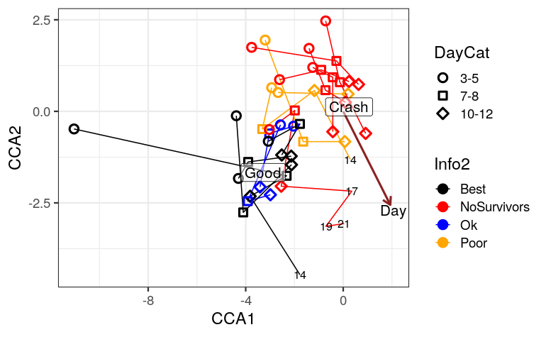

```r
early_days_fam <- family_cca_wa %>% filter(DayN < 14) %>% mutate(DayCat = droplevels(DayCat))
late_days_fam <- family_cca_wa %>% filter(DayN >= 14)
plt3 <- early_days_fam %>%
  ggplot(aes(x = CCA1, y = CCA2, shape = DayCat, group = `Brood#`, color = Info2)) +
  geom_path(aes(x = CCA1, y = CCA2, color = Info2, group = `Brood#`), data = family_cca_wa, inherit.aes = FALSE) +
  geom_point(size = 3, stroke = 1.5) +
  scale_shape_manual(values = c(21, 22, 23, 1, 1, 1, 1)) +
  #scale_shape_manual(values = c(21,22,23), breaks = c("3-5", "7-8", "10-12")) +
  scale_fill_manual(values = rep(c("green", "blue", "black"), 5)) +
  #scale_color_manual(values = c(Good = "black", Crash = "red")) +
  scale_color_manual(values = c(Best = "black", Ok = "blue", Poor = "Orange", NoSurvivors = "red")) +
  geom_text(data = late_days_fam, aes(x = CCA1, y = CCA2, label = DayCat), inherit.aes = FALSE) +
  geom_text(data = family_cca %>% fortify(display = "bp") %>% filter(label != "Info1Good") %>% mutate(label = str_remove(label, "N")), inherit.aes = FALSE, aes(x = CCA1 * 3.4, y = CCA2 * 3.4, label = label), size = 5) +
  geom_segment(data = family_cca %>% fortify(display = "bp") %>% filter(label != "Info1Good"), inherit.aes = FALSE, aes(x = 0, y = 0, xend = CCA1 * 3.2, yend = CCA2 * 3.2), color = "brown4",
               arrow = arrow(length = unit(0.3, "cm")), size = 1) +
  geom_label(data = family_cca %>% fortify(display = "cn") %>% mutate(label = str_remove(label, "Info1")), inherit.aes = FALSE, aes(x = CCA1, y = CCA2, label = label), alpha = 0.5, size = 5) +
  theme_bw(base_size = 16)
plt3
```

```r
metadata_limited <- metadata_main %>% filter(DayN < 14)
ratioDf_limited <- ratioDf[rownames(ratioDf) %in% metadata_limited$Sample0,]
second_cca <- cca(sqrt(ratioDf_limited) ~ DayN + Info1, data = metadata_limited)
anova(second_cca, by = "margin", permutations = 9999)
```

```
Permutation test for cca under reduced model
Marginal effects of terms
Permutation: free
Number of permutations: 9999

Model: cca(formula = sqrt(ratioDf_limited) ~ DayN + Info1, data = metadata_limited)
         Df ChiSquare      F Pr(>F)
DayN      1   0.08803 2.6896 0.0024 **
Info1     1   0.08139 2.4866 0.0036 **
Residual 41   1.34198
---
Signif. codes:  0 ‘***’ 0.001 ‘**’ 0.01 ‘*’ 0.05 ‘.’ 0.1 ‘ ’ 1
```

```r
minrat <- min(ratioDf_limited[ratioDf_limited>0])
second_rda <- rda(log(ratioDf_limited + minrat) ~ DayN + Info1, data = metadata_limited)
anova(second_rda, by = "margin", permutations = 9999)
```

```
Permutation test for rda under reduced model
Marginal effects of terms
Permutation: free
Number of permutations: 9999

Model: rda(formula = log(ratioDf_limited + minrat) ~ DayN + Info1, data = metadata_limited)
         Df Variance      F Pr(>F)
DayN      1    67.90 5.0085 0.0062 **
Info1     1    93.72 6.9130 0.0010 ***
Residual 41   555.85
---
Signif. codes:  0 ‘***’ 0.001 ‘**’ 0.01 ‘*’ 0.05 ‘.’ 0.1 ‘ ’ 1
```

Interaction test

```r
second_rda_ix <- rda(log(ratioDf_limited + minrat) ~ DayN * Info1, data = metadata_limited)
anova(second_rda_ix, by = "margin", permutations = 99999)
```

```
Permutation test for rda under reduced model
Marginal effects of terms
Permutation: free
Number of permutations: 99999

Model: rda(formula = log(ratioDf_limited + minrat) ~ DayN * Info1, data = metadata_limited)
           Df Variance      F  Pr(>F)
DayN:Info1  1    37.09 2.8596 0.04694 *
Residual   40   518.77
---
Signif. codes:  0 ‘***’ 0.001 ‘**’ 0.01 ‘*’ 0.05 ‘.’ 0.1 ‘ ’ 1
```

```r
metawhole <- metabeast %>%
  mutate(cca = map(.x = comm, ~cca(sqrt(.x) ~ Info1 + DayN, data = metadata_main)))
```

ratioDf_limited <- ratioDf[rownames(ratioDf) %in% metadata_limited$Sample0,]

```r
metawhole2 <- metabeast %>%
  mutate(comm_limited = map(comm, ~.[rownames(.) %in% metadata_limited$Sample0,])) %>%
  mutate(cca_limited = map(comm_limited, ~cca(sqrt(.) ~ Info1 + DayN, data = metadata_limited)))
```

```r
family_cca_limited <- metawhole2[metawhole2$taxlevel == "Family","cca_limited"][[1]][[1]]
anova(family_cca_limited, by = "margin", permutations = 9999)
```

```
Permutation test for cca under reduced model
Marginal effects of terms
Permutation: free
Number of permutations: 9999

Model: cca(formula = sqrt(.) ~ Info1 + DayN, data = metadata_limited)
         Df ChiSquare      F Pr(>F)
Info1     1   0.06128 1.7982 0.0042 **
DayN      1   0.06336 1.8593 0.0324 *
Residual 41   1.39726
---
Signif. codes:  0 ‘***’ 0.001 ‘**’ 0.01 ‘*’ 0.05 ‘.’ 0.1 ‘ ’ 1
```

```r
larvae_cca_plotter_limited <- function(second_cca){
second_cca_wa <- fortify(second_cca, display = "wa") %>%
  left_join(metadata_main, by = c("label" = "Sample0")) %>%
  mutate(DayCat = ordered(DayCat, levels = unique(DayCat))) %>%
  identity()
}

larvae_cca_plotter_limited(family_cca_limited)
```

family

## For proposal

And paper. Just red and blue (good vs crash).

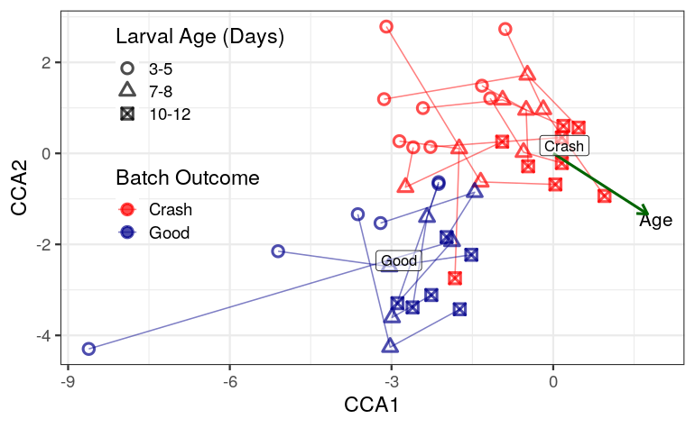

```r
larvae_cca_plotter_limited_prop <- function(second_cca){
second_cca_wa <- fortify(second_cca, display = "wa") %>%
  left_join(metadata_main, by = c("label" = "Sample0")) %>%
  mutate(DayCat = ordered(DayCat, levels = unique(DayCat))) %>%
  identity()


early_days <- second_cca_wa %>% filter(DayN < 14) %>% mutate(DayCat = droplevels(DayCat))
late_days <- second_cca_wa %>% filter(DayN >= 14)
plt2 <- early_days %>%
  ggplot(aes(x = CCA1, y = CCA2, shape = DayCat, group = `Brood#`, color = Info1)) +
  geom_path(aes(x = CCA1, y = CCA2, color = Info1, group = `Brood#`), alpha = 0.5, data = second_cca_wa, inherit.aes = FALSE) +
  geom_point(size = 3, stroke = 1.5, alpha = 0.7) +
  scale_shape_manual(values = c(1, 2, 7, 1, 1, 1, 1), name = "Larval Age (Days)") +
  #scale_shape_manual(values = c(21,22,23), breaks = c("3-5", "7-8", "10-12")) +
  #scale_fill_manual(values = rep(c("green", "blue", "black"), 5)) +
  scale_color_manual(values = c(Good = "darkblue", Crash = "red"), name = "Batch Outcome") +
  #scale_color_manual(values = c(Best = "black", Ok = "blue", Poor = "Orange", NoSurvivors = "red")) +
  geom_text(data = late_days, aes(x = CCA1, y = CCA2, label = DayCat), inherit.aes = FALSE) +
  geom_text(data = second_cca %>% fortify(display = "bp") %>% filter(label != "Info1Good") %>% mutate(label = str_remove(label, "N")) %>% mutate(label = str_replace(label, "Day", "Age")), inherit.aes = FALSE, aes(x = CCA1 * 2.4, y = CCA2 * 2.4, label = label), size = 5) +
  geom_segment(data = second_cca %>% fortify(display = "bp") %>% filter(label != "Info1Good"), inherit.aes = FALSE, aes(x = 0, y = 0, xend = CCA1 * 2.2, yend = CCA2 * 2.2), color = "darkgreen",
               arrow = arrow(length = unit(0.3, "cm")), size = 1) +
  geom_label(data = second_cca %>% fortify(display = "cn") %>% mutate(label = str_remove(label, "Info1")), inherit.aes = FALSE, aes(x = CCA1, y = CCA2, label = label), alpha = 0.5, size = 4) +
  theme_bw(base_size = 16) +
  theme(legend.position = c(.225, .65), legend.background = element_blank())

plt2
}

pre_prop_fig1 <- larvae_cca_plotter_limited_prop(family_cca_limited)
pre_prop_fig1
```

```r
ggsave(here("Figures", "Pre_Prop_Fig1.png"), pre_prop_fig1, height = 5, width = 6)
```

Plot interactions

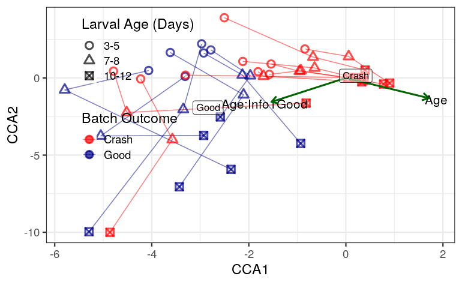

```r
plot_ix <- larvae_cca_plotter_limited_prop(second_cca_ix)
plot_ix
```

I wonder if I could add families scores to this latest plot.

```r
family_cca %>% fortify(display = "species")
```

| score | label | CCA1 | CCA2 | CA1 | CA2 | CA3 | CA4 |
| --- | --- | --- | --- | --- | --- | --- | --- |
| species | 0319-6G20 | 0.066762155 | 0.468031667 | -8.617111e-02 | -0.6493660486 | -0.096722786 | -0.437672198 |
| species | 37-13 | 0.182879817 | 0.239506707 | -6.363094e-03 | 0.0588495084 | 0.279798095 | -0.146492172 |
| species | 67-14 | -0.388771421 | 0.010652653 | -1.694041e-01 | 0.0192031723 | 0.068220200 | -0.244796448 |
| species | A0839 | 0.206936247 | 0.192162534 | -5.459083e-02 | -0.6958063336 | 0.345302619 | 0.195602743 |
| species | A4b | 0.048385892 | 0.152661737 | -6.879872e-02 | -0.1935109049 | 0.207671872 | -0.228641286 |
| species | AEGEAN-169_marine_group | 0.379093426 | -0.146650803 | -9.558703e-02 | 0.0943641172 | -0.490045846 | -0.887744670 |
| species | AKYG1722 | -3.437955914 | -1.363777000 | -9.980407e-01 | 0.5196238279 | -0.050686489 | -0.565304817 |
| species | Acanthoecidae_fa | -0.234408191 | 1.060748919 | -6.980419e-02 | -0.2963388624 | -0.352575697 | -1.353883020 |
| species | Acanthopleuribacteraceae | 0.062956063 | 0.232059204 | 6.909683e-02 | -0.2980234194 | 0.207366756 | 0.003922108 |
| species | Acetobacteraceae | -0.387535952 | -0.716504016 | -7.579038e-03 | 0.8746078149 | 0.607228795 | 0.303010670 |

[output cut: 303 more lines]

But really I just want frequent families.